# Longitudinal Psychometric Network Modelling

Developments and Challenges

Florian Metwaly

University of Amsterdam

September 2026

## Recap

- Two fundamental questions:
  - Is there an effect? → hypothesis testing
    - Evidence of absence, absence of evidence
  - What is the effect? → estimation
- We can already answer many questions by looking at a single time point!

## Motivation

- Psychological research is concerned with what happens within **one** person
- Increasing collection of (intensive) longitudinal data
  - Panel studies
  - Diary studies
  - Wearables
  - Experience sampling/EMA
- Increasing interest in the estimation of dependency structures
- In psychology/psychometrics but also other fields (econometrics, political science, biology)

## Challenges of Longitudinal Data

| Statistical challenges | Conceptual challenges |
| --- | --- |
| Dependent observations | Interpretation |
| Data types | Discrete observations of continuous processes |
| Missing data | Time scale |
| Model selection | Causality |
| Computational complexity | Prediction versus inference |
| **Uncertainty quantification** | Population versus individual networks |

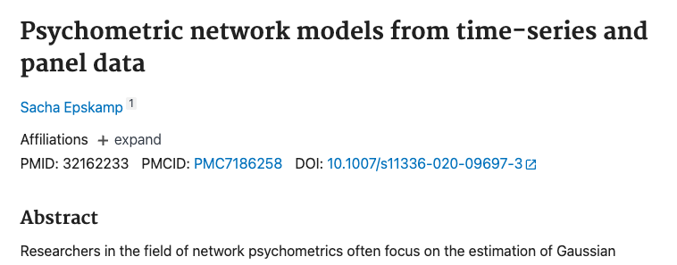

[figure not shown]

[figure not shown]

[figure not shown]

[figure not shown]

[figure not shown]

[figure not shown]

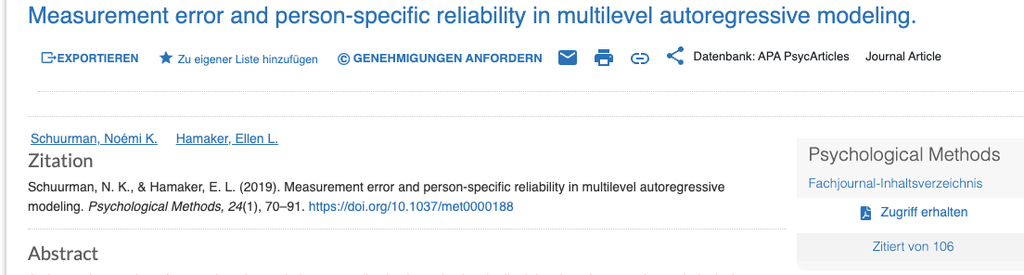

## Modelling and software options

- CLPM
- DSEM
- GAMM
- ARIMA/SARIMA
- State-space modelling (HMM)
- `(b)lavaan`
- `mlVar`
- `tsnet`
- `graphicalVAR`
- `dynamite`

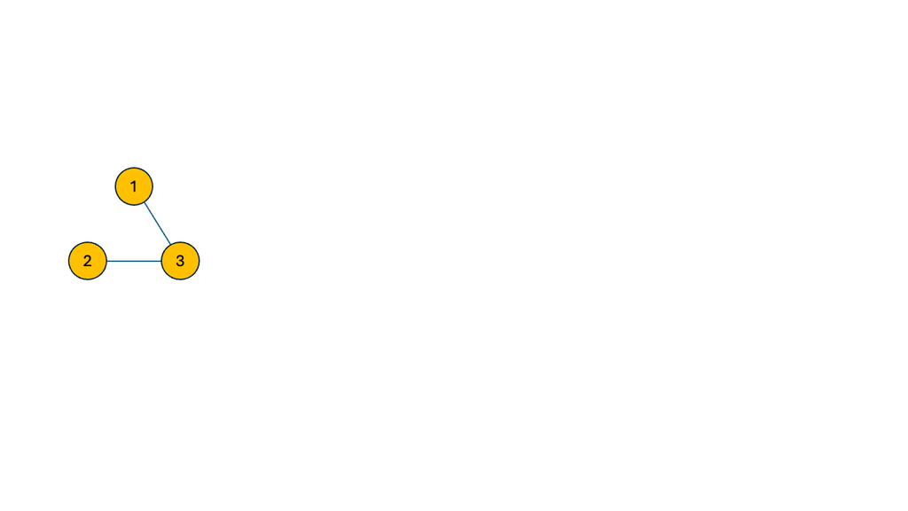

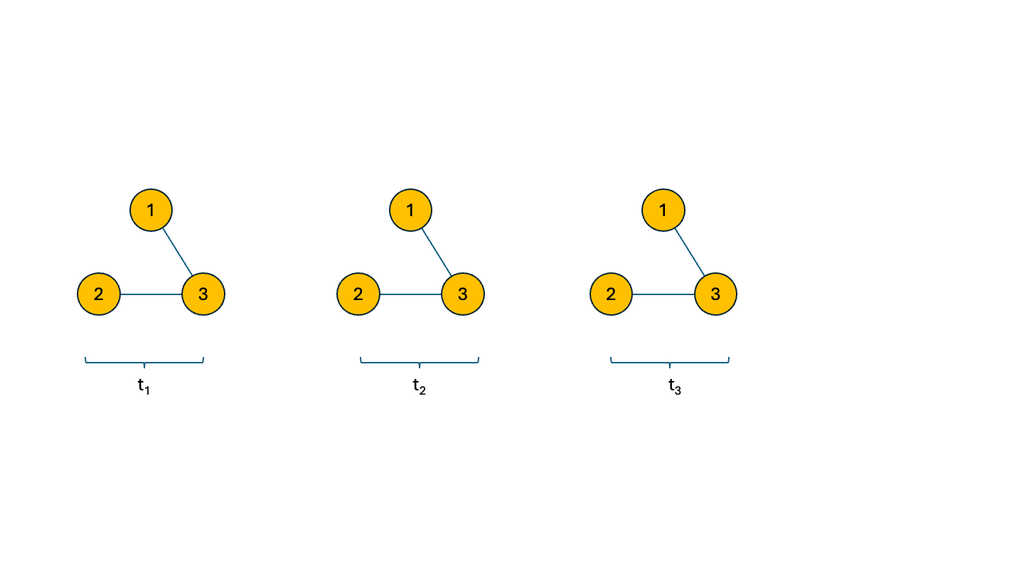

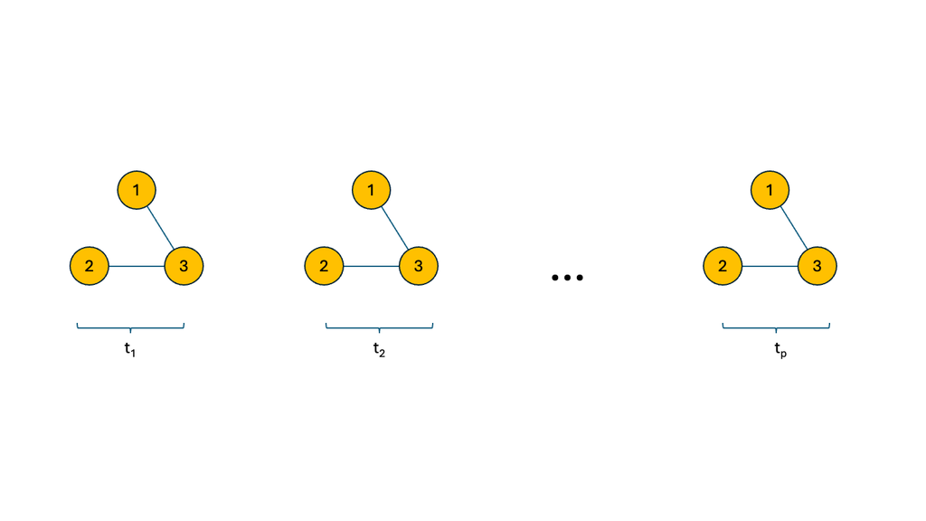

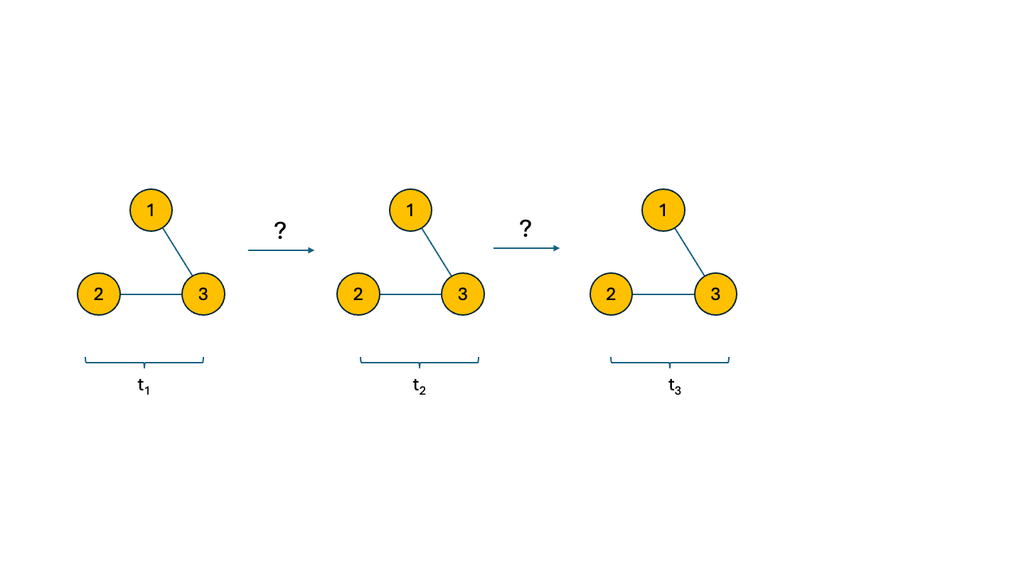

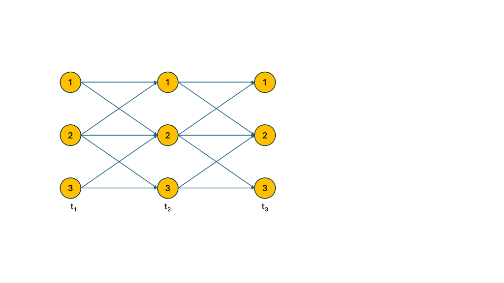

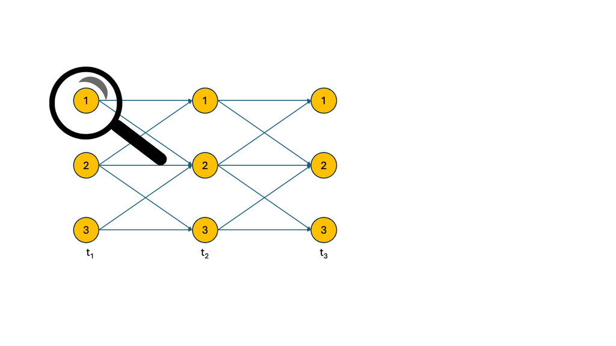

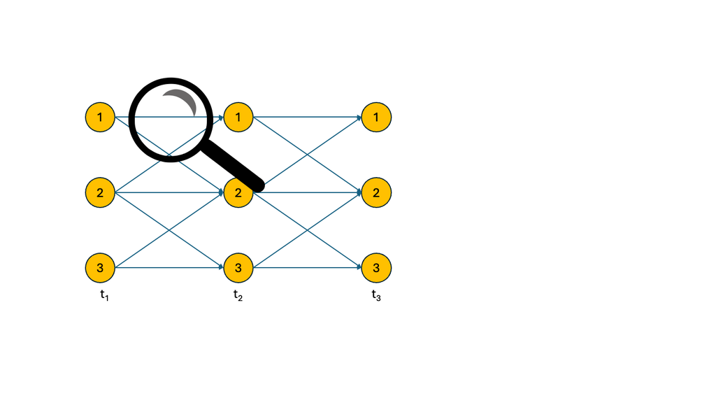

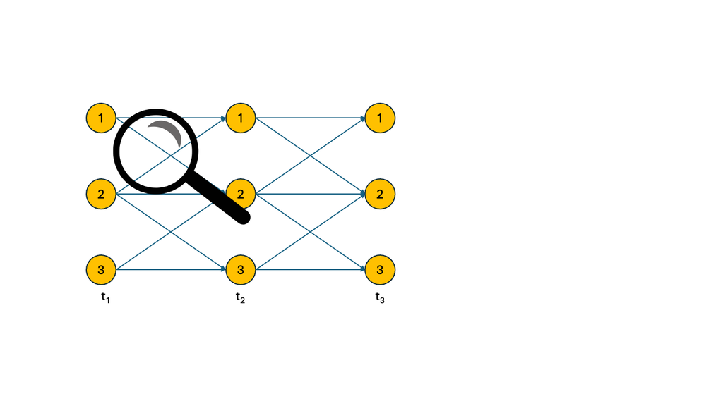

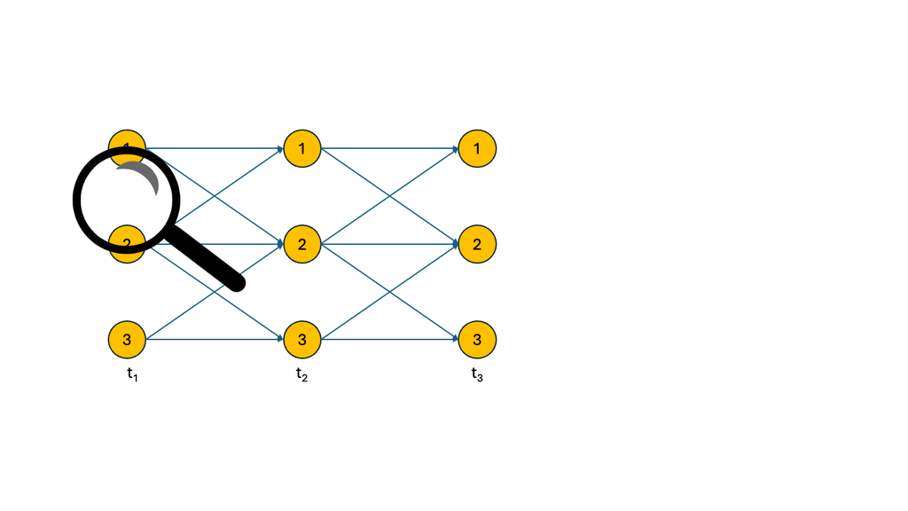

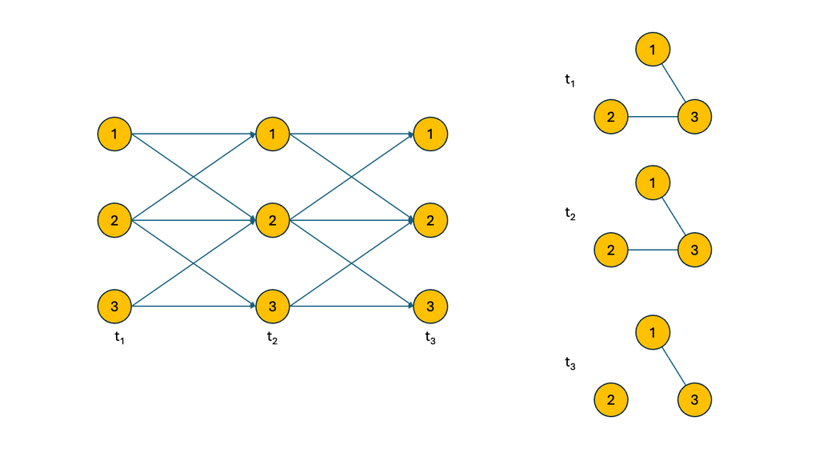

## Uncertainty in longitudinal networks

- Does the state of variable 1 at $t$ predict its state at $t+1$ ($t+2$, $t+3$, …)?
- Does the state of variable 1 at $t$ predict the state of variable **2** at $t$ effect $t+1$ ($t+2$, $t+3$, …)?
- Does a covariate (treatment group, previous depressive episodes, …) influence the network’s temporal structure?
- Are two variables still conditionally (in)dependent at $t$ when accounting for the temporal structure?
- How certain are we about the presence or absence of certain edges in a network?

## Uncertainty in longitudinal networks

Suppose we estimate an edge from sadness at $t$ to sleep at $t+1$.

- **Existence:** Is there evidence that the edge is present?
- **Magnitude:** How large and in which direction is the association?
- **Heterogeneity:** Is the association the same for every person?
- **Time scale:** Does it appear at $t+1$, $t+2$, or another lag?
- **Prediction:** How uncertain are the resulting predictions?
- The network models relationships within a dynamic process
- Bayesian estimation quantifies the uncertainty about those relationships

## Vector autoregression

- A VAR($k$) models the current state using the previous $k$ states:

$$\mathbf{y}_t
=
\boldsymbol{\alpha}
+
\sum_{\ell=1}^{k}
\boldsymbol{\Phi}_{\ell}\mathbf{y}_{t-\ell}
+
\boldsymbol{\varepsilon}_t$$

- The innovations follow a multivariate normal distribution:

$$\boldsymbol{\varepsilon}_t
\sim
N_p
\left(
\mathbf{0},
\boldsymbol{\Sigma}
\right)$$

- A Gaussian graphical model describes their conditional dependence structure:

$$\boldsymbol{\Omega}
=
\boldsymbol{\Sigma}^{-1}$$

- The nonzero off-diagonal elements of $\boldsymbol{\Omega}$ define the cross-sectional network
- Modelling the temporal network and the cross-sectional network jointly results in a **graphical VAR**

# Current challenges and developments

## bvarnet

$$y_i \sim D(f(\eta_i), \theta) \\
\eta = \underbrace{X\beta}_{\text{fixed effects}} + \underbrace{B\phi}_{\text{temporal structure}} + \underbrace{Zu}_{\text{random effects}}$$

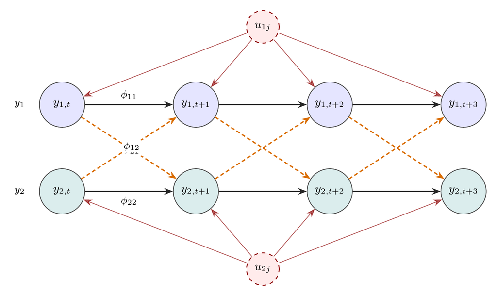

- $D()$ = Distribution with parameters $\theta$
- $f()$ = Inverse-link function
- $\eta_i$ = Linear predictor
- $X, B, Z$ = Design matrices
- $\beta, \phi, u$ = Parameter vectors

## Outcome families

#### Gaussian

*Identity link*

$$\scriptsize y_{i} \sim N(\eta_{i}, \sigma_i^2)$$

#### Binary

*Logit link*

$$\scriptsize y_{i} \sim \text{Bernoulli}\!\left( \text{logit}^{-1}(\eta_{i}) \right)$$

#### Ordinal

*Adjacent-category logit*

$$\scriptsize \log \frac{P(y_{i} = c)}{P(y_{i} = c-1)} = \eta_{i} - \kappa_{ic}$$

## Workflow

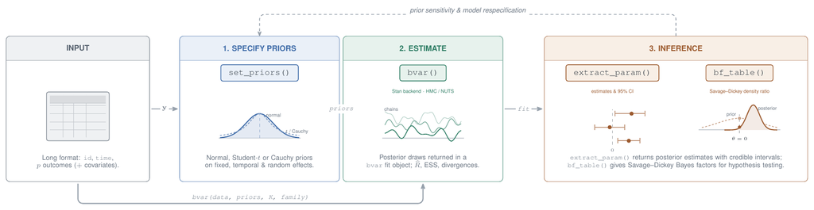

## Studentlife data

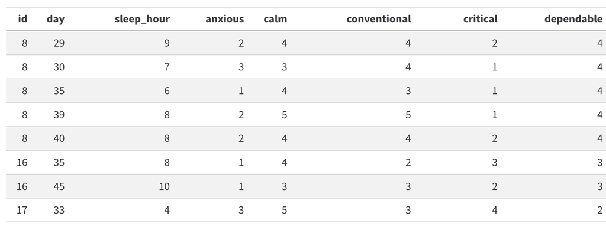

(Wang et al., 2014)

- Network of 5 variables
  - `anxious`, `calm`, `conventional`, `critical`, `dependable`
- One time-varying covariate
  - `sleep_hour`
- 49 participants
- 65 time points

## set_priors()

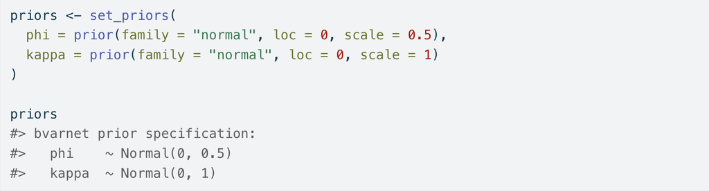

## bvar()

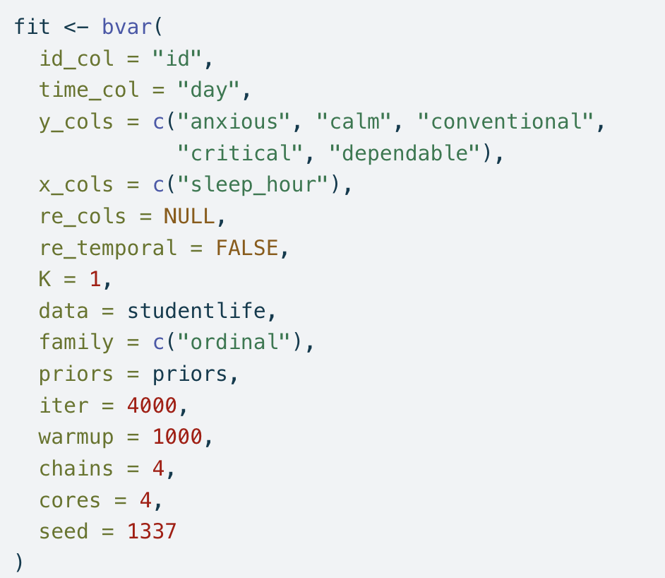

[figure not shown]

## print()

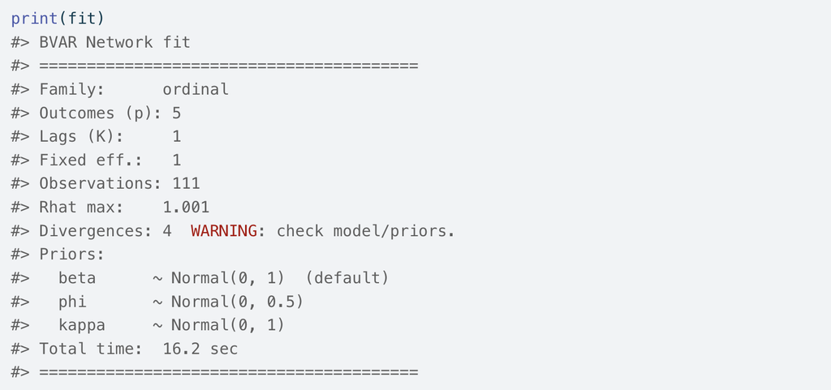

## summary()

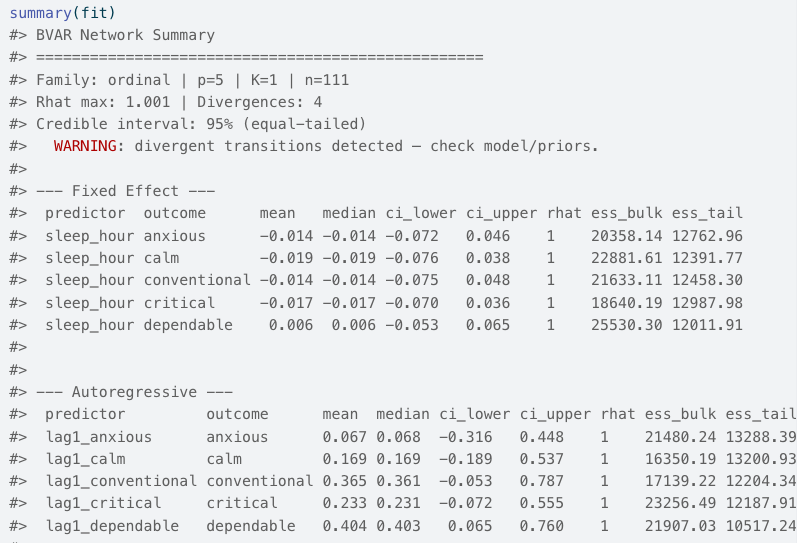

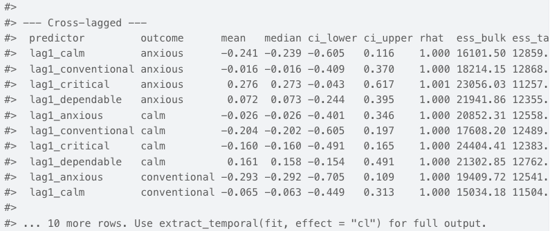

## bf_table()

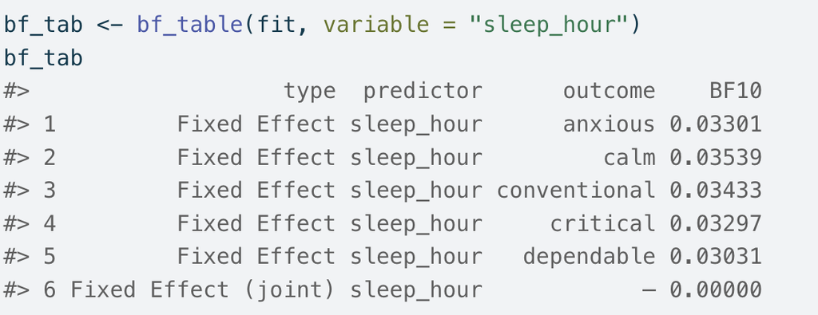

## Plot network

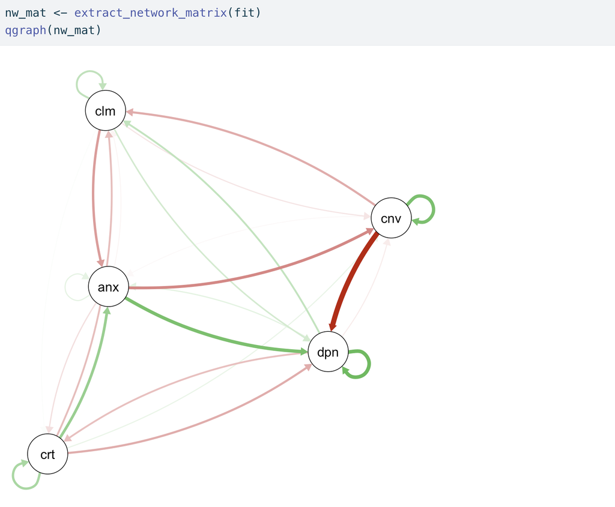

## Conclusion

- Longitudinal networks can describe temporal and cross-sectional relationship within (intensive) longitudinal data
- A lot of software and methods exits, but we are missing a coherent framework
- Bayesian estimation is used for proper uncertainty quantification
- Faces many challenges, statistical as well as conceptual

## Recommended reading

[figure not shown]

Borsboom, D., Deserno, M. K., Rhemtulla, M., Epskamp, S., Fried, E. I., McNally, R. J., Robinaugh, D. J., Perugini, M., Dalege, J., Costantini, G., Isvoranu, A.-M., Wysocki, A. C., van Borkulo, C. D., van Bork, R., & Waldorp, L. J. (2021). Network analysis of multivariate data in psychological science. Nature Reviews Methods Primers, 1, Article 58. https://doi.org/10.1038/s43586-021-00055-w

## Practical

```r
install.packages("bvarnet")
bvarnet::bvarnet_setup_models(method = "download") # easy installation

# or if you have CmdStanR setup
bvarnet::bvarnet_setup_models(method = "compile")
```

https://github.com/flo1met/Workshops/tree/main/IOPS_2026